# Lab 11

WADDS

April 4, 2018

## First Three Letters of Names

Overall, the ratio of names in the dataset that start with the first three letters of Abby divided by total names that contain (in order) the first three letters of the Abby is 0.96522, or about 96.52%, which means most names with abb in them also begin with Abb.

```
## Observations: 656
## Variables: 3
## $ group <chr> "Abb", "Abb", "Abb", "Abb", "Abb", "Abb", "Abb", "Abb", ...
## $ year  <dbl> 1880, 1881, 1882, 1883, 1884, 1885, 1886, 1887, 1888, 18...
## $ n     <int> 82, 88, 91, 79, 109, 93, 91, 114, 152, 115, 152, 146, 12...
```

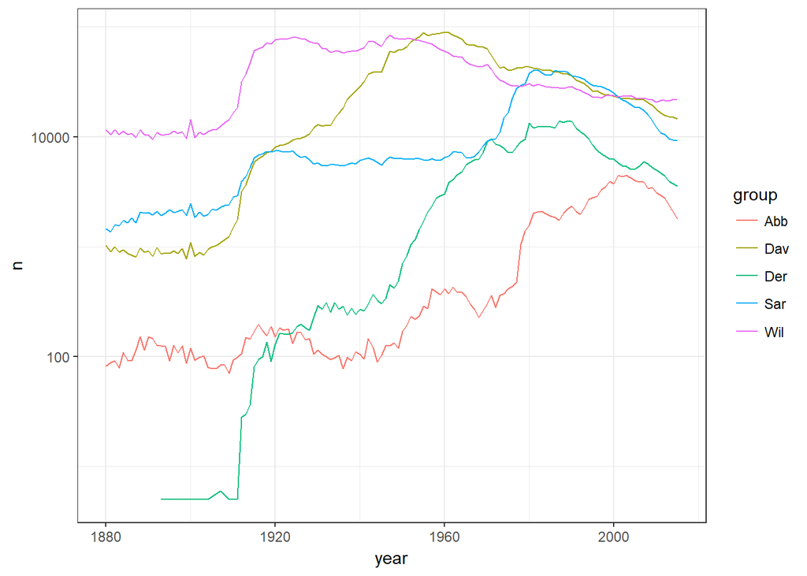

```
## $title
## [1] "Group names"
##
## $subtitle
## NULL
##
## attr(,"class")
## [1] "labels"
```

## Rachel and Ariel Regexs

Using the RegEx “Ar[iy]+.l+[^a]?$” we found that in 1973 there were 2 different spelling sof the name Ariel, in 1988 there were 7 different spellings, and in 1990 there were 8 different spellings of the name Ariel. This could indicate an overall increase in the popularity of the name Ariel over the years. Using the RegEx “Ra[ey]?ch.*l" we found that in 1973 there wer 13 different spellings of the name Rachel, int 1988 there were 19 different spellings, and in 1990 there were 17 different spellings of the name Rachel. This would indicate a slight increase in Rachel’s around 1988, with the popularity decreasing again around 1990.

We also calculated the probability of being named either Rachel or Ariel in 1973 as around .28%, which continued to increase to .57% by 1988 and then again to .61% by 1990. This supports an overall trend observed in the increasing popularity of the name Ariel, and refelcts the slight increase in the popularity of Rachel around 1988. The likelihood of a girl being named Rachel or Ariel has increased over the years likely because of an increase in the popularity of those names.

## The Little Mermaid Effect

In this problem, we aim to find out if the movie, The Little Mermaid, preimiring in 1989 had an affect on little girls being names Ariel in the United States. In order to do this, we compared the change in proportion of girls names Ariel with the change in proportion of all girl names beginning with a vowel.

The plot below is a histogram of the change in proportion of all girls names starting with a vowel from 1988 to 1990. The vertical line represents the change in proportion of the name Ariel specifically given the time period.

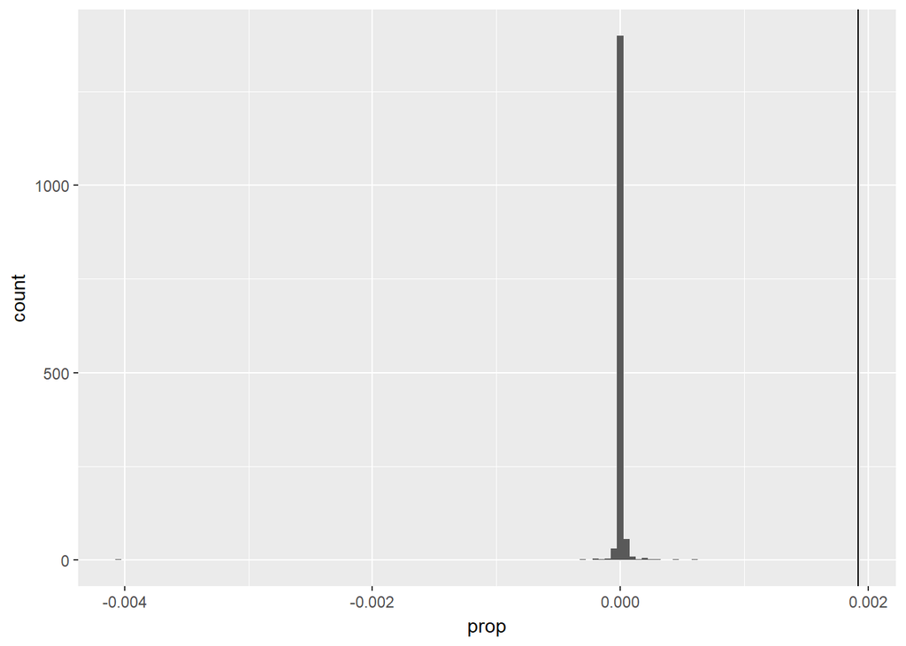